# ARIMA_model_initial

# Here, we apply the ARMA model for the first wikipedia page - 2NE1_zh.wikipedia.org

```r
# basic imports
library("fpp", lib.loc="C:/Users/HP/Anaconda3/envs/rstudio/lib/R/library")
library("ggplot2", lib.loc="C:/Users/HP/Anaconda3/envs/rstudio/lib/R/library")
library("xts", lib.loc="C:/Users/HP/Anaconda3/envs/rstudio/lib/R/library")
library("zoo", lib.loc="C:/Users/HP/Anaconda3/envs/rstudio/lib/R/library")
```

### Importing the data

```r
setwd("D:/USMS/UChicago/STUDIES/Autumn 2020/MSCA 31006 1 Time Series Analysis and Forecasting/Final Project/Data")
page_2NE1_views <- data.matrix(read.csv("train_1.csv", header = TRUE, row.names = 1,sep = ",",nrows = 1,skip =0))
```

### Preparing data to make it ready for time-series

```r
# removing column names
dimnames(page_2NE1_views) <- NULL

# converting to array
page_2NE1_views <- array(page_2NE1_views)

# checking the values
head(page_2NE1_views)
```

```
## [1] 18 11  5 13 14  9
```

```r
# no. of ovservations
length(page_2NE1_views)
```

```
## [1] 550
```

So, we see that there are 550 observations, i.e. number of views for the wikipedia page for 550 days from 1st July 2015 till 31st Dec 2016

Let’s convert it to time-series and then split it to train and test - we will train our models for the period 1st July 2015 till 20th Dec 2016 and we will forecast for 21st Dec 2016 to 31st Dec 2016

```r
# converting to time-series
time_index <- seq(from = as.POSIXct("2015-07-01"),to = as.POSIXct("2016-12-31"), by = "day")
page_2NE1_views_ts <- xts(page_2NE1_views, order.by =time_index ,frequency = 365.25)

# checking first few values
head(page_2NE1_views_ts)
```

```
##            [,1]
## 2015-07-01   18
## 2015-07-02   11
## 2015-07-03    5
## 2015-07-04   13
## 2015-07-05   14
## 2015-07-06    9
```

```r
# splitting to train and test
page_2NE1_views_ts_train <- page_2NE1_views_ts['2015-07-01/2016-12-20']
page_2NE1_views_ts_test <- page_2NE1_views_ts['2016-12-21/2016-12-31']

# viewing the train and test
head(page_2NE1_views_ts_train)
```

```
##            [,1]
## 2015-07-01   18
## 2015-07-02   11
## 2015-07-03    5
## 2015-07-04   13
## 2015-07-05   14
## 2015-07-06    9
```

```r
tail(page_2NE1_views_ts_train)
```

```
##                     [,1]
## 2016-12-15 23:00:00   18
## 2016-12-16 23:00:00   21
## 2016-12-17 23:00:00   21
## 2016-12-18 23:00:00   47
## 2016-12-19 23:00:00   65
## 2016-12-20 23:00:00   17
```

```r
page_2NE1_views_ts_test
```

```
##                     [,1]
## 2016-12-21 23:00:00   32
## 2016-12-22 23:00:00   63
## 2016-12-23 23:00:00   15
## 2016-12-24 23:00:00   26
## 2016-12-25 23:00:00   14
## 2016-12-26 23:00:00   20
## 2016-12-27 23:00:00   22
## 2016-12-28 23:00:00   19
## 2016-12-29 23:00:00   18
## 2016-12-30 23:00:00   20
```

Now, let’s look at our train data.

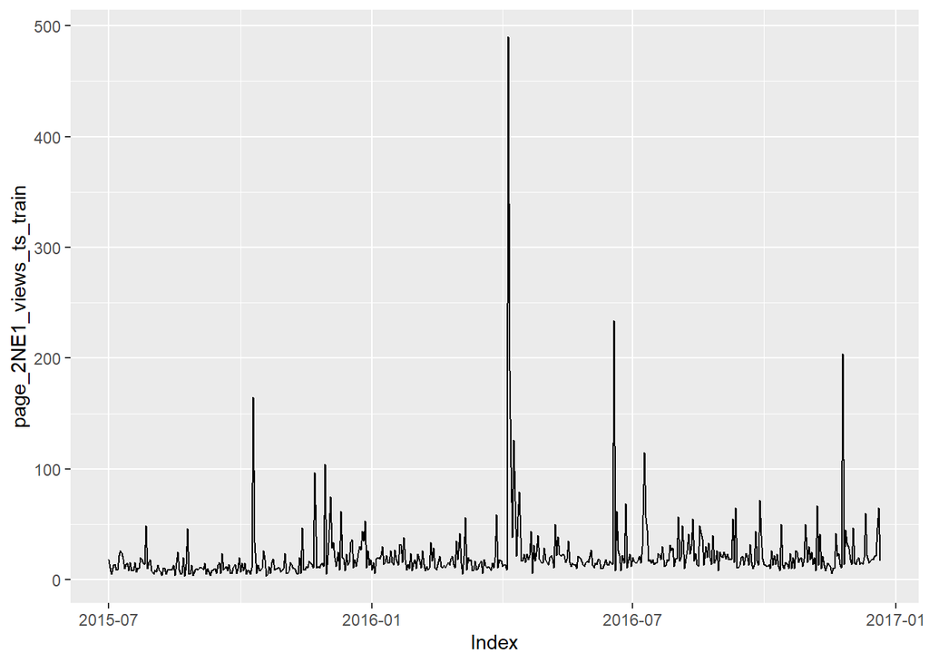

```r
autoplot(page_2NE1_views_ts_train)
```

From the first look of the time-series, we see that there are few outliers. We see that after the occurence of this outlier, the level of the time-series did not change, hence this outlier **is not an intervention**. So, we can replace this value with the mean of all observations to maintain sanity.

```r
# replacing the outlier with mean
page_2NE1_views_ts_train[page_2NE1_views_ts_train>=150]
```

[output not shown]

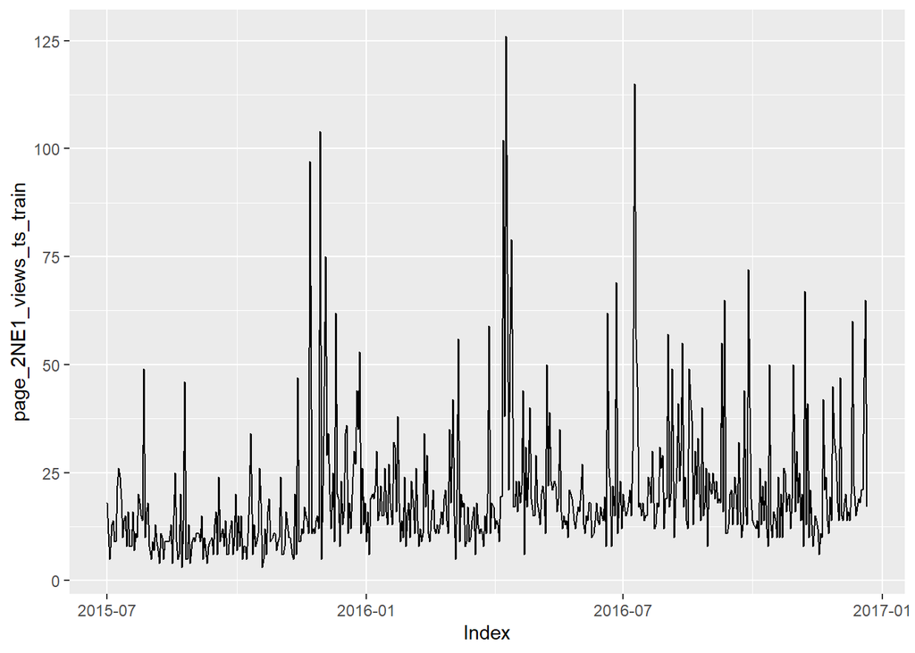

```r
page_2NE1_views_ts_train[page_2NE1_views_ts_train>150] <- mean(page_2NE1_views_ts_train[!page_2NE1_views_ts_train>=150])

# plotting
autoplot(page_2NE1_views_ts_train)
```

Looks much better now. But we that the variance is increasing over time, so transformation of data might be needed to de-couple variance from the mean.

Transforming the data –>

```r
# finding ideal lambda
BoxCox.lambda(page_2NE1_views_ts_train)
```

```
## [1] -0.3565587
```

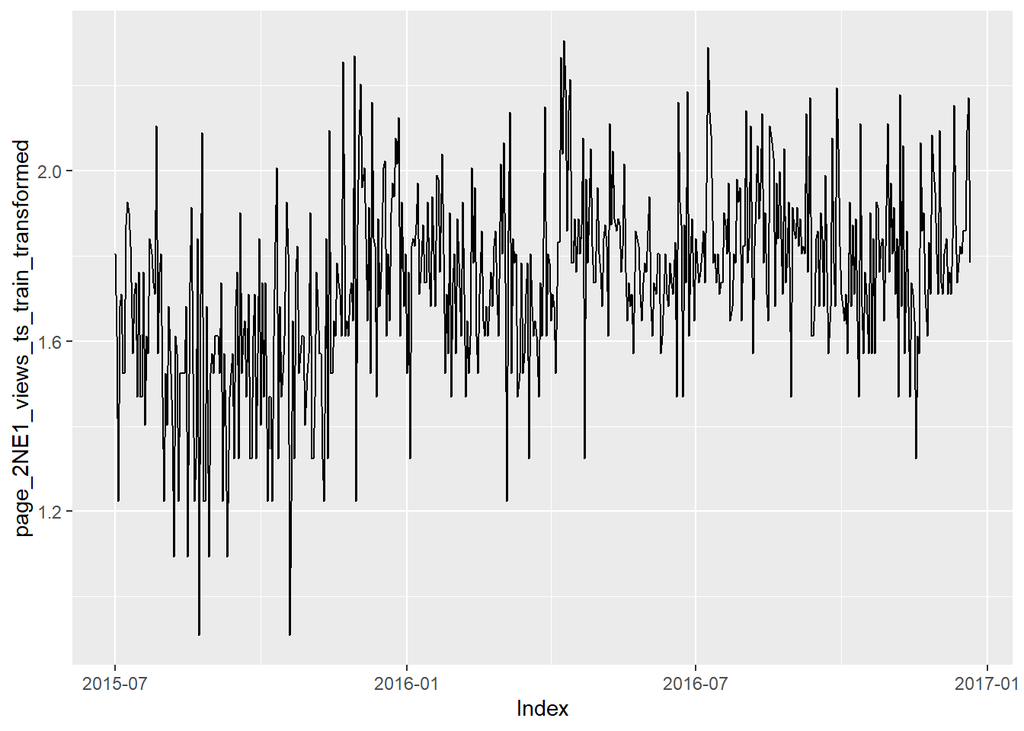

```r
# transforming the data
page_2NE1_views_ts_train_transformed <- BoxCox(page_2NE1_views_ts_train,lambda = -0.3565587)

# visualizing again
autoplot(page_2NE1_views_ts_train_transformed)
```

Few things we can notice about the time-series ->

1. It has a slight non-seasonal and long-term trend
2. Might be a hint of cyclical component
3. Seasonal component might be present.
4. The level does not seem constant over time

Now, let’s look at the ACF and PACF for this time-series

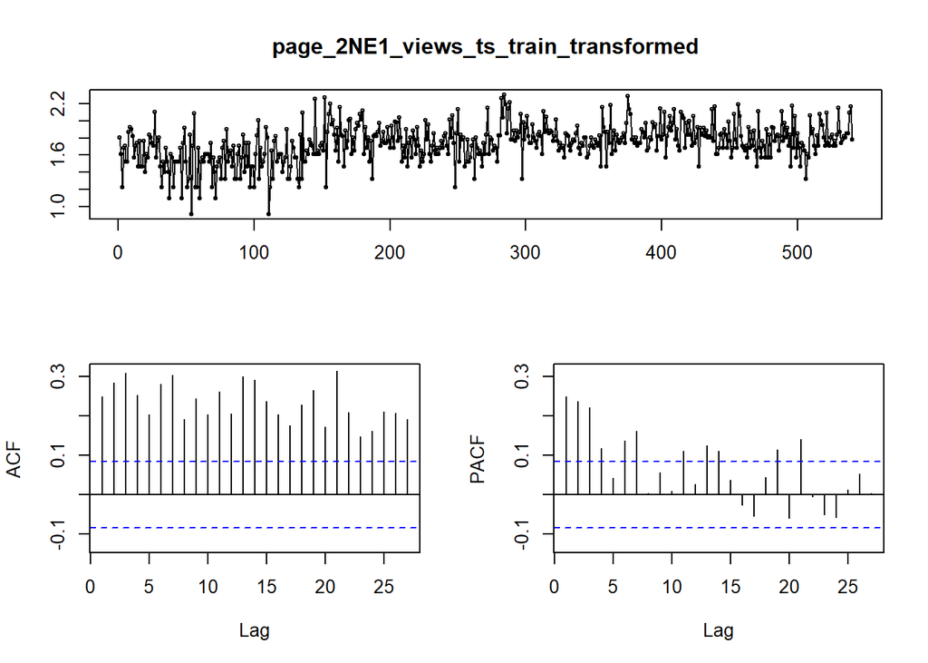

```r
tsdisplay(page_2NE1_views_ts_train_transformed)
```

From the ACF/PACF we can see –>

1. There is very slow decay of the ACF which indicates this data is **NOT stationary**. There is a hint of sinusoidal component as well
2. There is decay of ACF and drop in PACF after lag 3, this might be an indication that we can apply AR model with order = 3

Applying KPSS test to check stationarity –>

```r
kpss.test(page_2NE1_views_ts_train_transformed)
```

```
##
##  KPSS Test for Level Stationarity
##
## data:  page_2NE1_views_ts_train_transformed
## KPSS Level = 3.4126, Truncation lag parameter = 6, p-value = 0.01
```

The p-value = 0.01  
=> We reject the NULL hypothesis  
=> The data is **NOT stationary**

So, to handle the non-seasonal non-stationarity, let’s apply 1 order of non-seasonal differencing

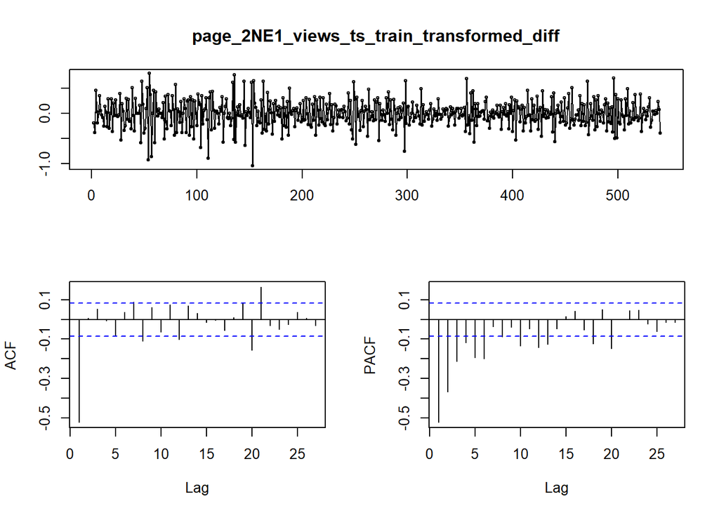

```r
# applying 1st order differencing
page_2NE1_views_ts_train_transformed_diff <- diff(page_2NE1_views_ts_train_transformed)

# visualizing data
tsdisplay(page_2NE1_views_ts_train_transformed_diff)
```

Now, we can see from time-series plot the data appears stationary. From the ACF, we can see that there is no more slow decay, which indicates it **is stationary**.

Let’s confirm this with KPSS test

```r
kpss.test(page_2NE1_views_ts_train_transformed_diff)
```

```
##
##  KPSS Test for Level Stationarity
##
## data:  page_2NE1_views_ts_train_transformed_diff
## KPSS Level = 0.010047, Truncation lag parameter = 6, p-value = 0.1
```

Here, p-value = 0.1  
=> The data **is stationary**

Applying auto.arima

```r
auto.arima(page_2NE1_views_ts_train,lambda = "auto", d=1)
```

```
## Series: page_2NE1_views_ts_train
## ARIMA(1,1,1)
## Box Cox transformation: lambda= -0.3565587
##
## Coefficients:
##           ar1      ma1
##       -0.0404  -0.9098
## s.e.   0.0475   0.0212
##
## sigma^2 estimated as 0.03868:  log likelihood=111.79
## AIC=-217.58   AICc=-217.54   BIC=-204.71
```

Applying the model suggested by auto.arima

```r
m1 <- auto.arima(page_2NE1_views_ts_train,lambda = "auto", d=1)
m1
```

```
## Series: page_2NE1_views_ts_train
## ARIMA(1,1,1)
## Box Cox transformation: lambda= -0.3565587
##
## Coefficients:
##           ar1      ma1
##       -0.0404  -0.9098
## s.e.   0.0475   0.0212
##
## sigma^2 estimated as 0.03868:  log likelihood=111.79
## AIC=-217.58   AICc=-217.54   BIC=-204.71
```

Forecasting

```r
forecast(m1,h=10)
```

```
##          Point Forecast    Lo 80    Hi 80    Lo 95     Hi 95
## 46656001       22.01298 11.24483 53.33905 8.333532  98.48998
## 46742401       21.77404 11.14038 52.61502 8.261015  96.91200
## 46828801       21.78362 11.11853 52.85890 8.237401  97.72969
## 46915201       21.78324 11.09374 53.06269 8.212224  98.45039
## 47001601       21.78325 11.06923 53.26844 8.187314  99.17982
## 47088001       21.78325 11.04488 53.47444 8.162594  99.91372
## 47174401       21.78325 11.02070 53.68078 8.138065 100.65230
## 47260801       21.78325 10.99667 53.88744 8.113724 101.39560
## 47347201       21.78325 10.97280 54.09444 8.089568 102.14367
## 47433601       21.78325 10.94908 54.30178 8.065595 102.89654
```

Visualizing the forecast

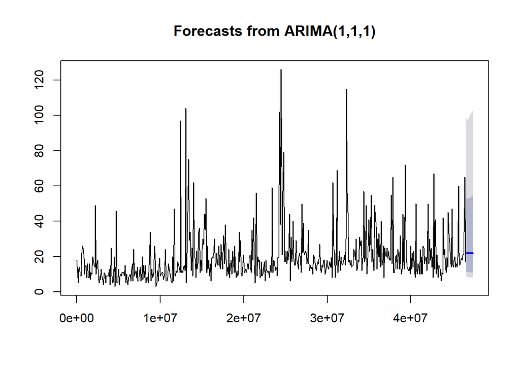

```r
plot(forecast(m1,h=10))
```

Checking model performance

```r
accuracy(forecast(m1,h=10),page_2NE1_views_ts_test)
```

```
##                    ME     RMSE      MAE       MPE     MAPE      MASE
## Training set 3.746718 15.07120 8.092188 -7.404354 39.11938 0.4148846
## Test set     3.094662 13.97199 8.034637 -4.046705 26.81691 0.4119340
##                  ACF1
## Training set 0.114827
## Test set           NA
```

```r
Model_Mean <- meanf(page_2NE1_views_ts_train, h=10)
Model_Naive <- naive(page_2NE1_views_ts_train, h=10)
Model_Drift <- rwf(page_2NE1_views_ts_train, h=10, drift=TRUE)

accuracy(Model_Mean,page_2NE1_views_ts_test)
```

```
##                        ME     RMSE      MAE        MPE     MAPE      MASE
## Training set 3.158036e-16 15.12685 9.482243 -43.834100 63.98949 1.0000000
## Test set     5.395327e+00 14.66286 7.799065   6.900008 22.97315 0.8224916
```

```r
accuracy(Model_Naive,page_2NE1_views_ts_test)
```

```
##                        ME     RMSE      MAE       MPE     MAPE      MASE
## Training set -0.001855288 19.21172 11.71989 -33.49642 70.70281 0.6008758
## Test set      7.900000000 15.75754  8.90000  18.85535 25.80773 0.4563009
##                   ACF1
## Training set -0.515585
## Test set            NA
```

```r
accuracy(Model_Drift,page_2NE1_views_ts_test)
```

```
##                        ME     RMSE       MAE       MPE     MAPE      MASE
## Training set 3.831969e-16 19.21172 11.719952 -33.48273 70.70009 0.6008792
## Test set     7.910204e+00 15.76025  8.907236  18.90754 25.83925 0.4566719
##                   ACF1
## Training set -0.515585
## Test set            NA
```

So, we see that our model test RMSE is better than that of all naive models.

Let’s see how the residuals are.

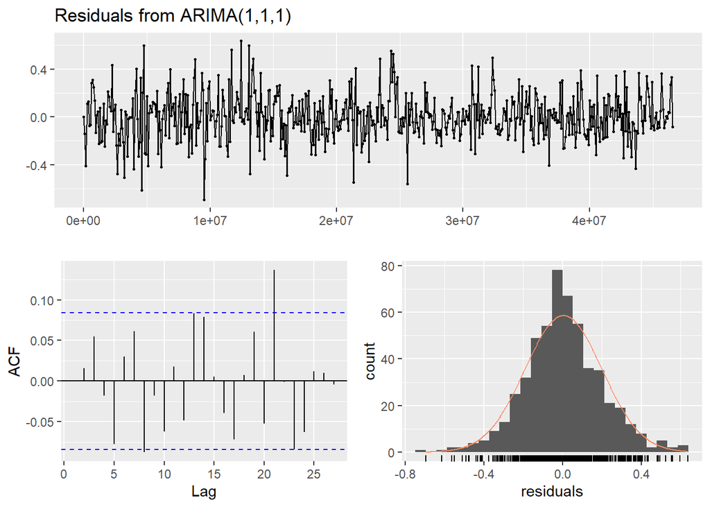

```
##
##  Ljung-Box test
##
## data:  Residuals from ARIMA(1,1,1)
## Q* = 14.395, df = 8, p-value = 0.07203
##
## Model df: 2.   Total lags used: 10
```

```r
checkresiduals(m1)
```

From the time-series of the residuals, we see that its mean = 0 => our model is not biased.

From ACF plot, we see that the ACF of the residuals are almost white noise. There is no significant correlations between the residuals. This implies that our model performed well.There is one significant spike at lag 21. But I believe we can live with it.  
From the histogram, we can see that the residuals are fairly normally distributed.

Let’s check the QQ plot as well

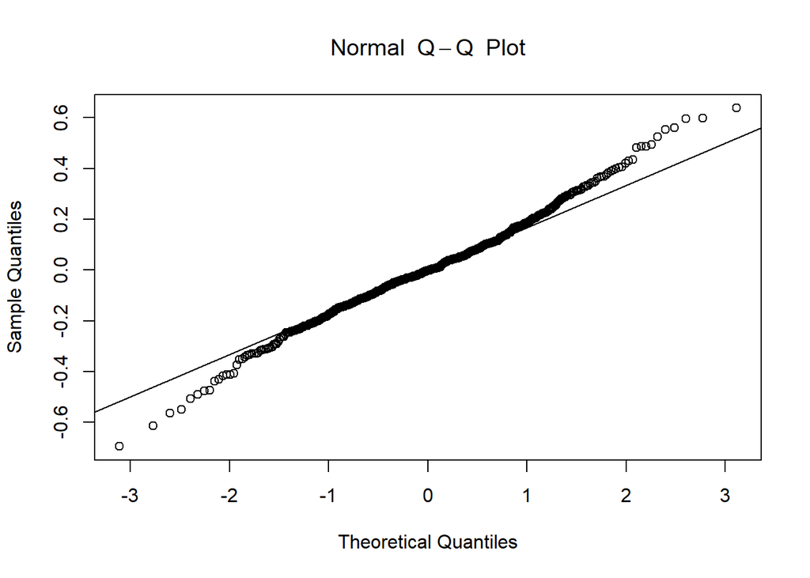

```r
qqnorm(m1$residuals,main=expression(Normal~~Q-Q~~Plot))
qqline(m1$residuals)
```

The residuals seem to be fairly normally distributed with few outliers.

Now, let’s try forecasting with ETS model and see how it turns out.

```r
m2 <- ets(page_2NE1_views_ts_train,lambda = "auto")
m2
```

```
## ETS(A,N,N)
##
## Call:
##  ets(y = page_2NE1_views_ts_train, lambda = "auto")
##
##   Box-Cox transformation: lambda= -0.3566
##
##   Smoothing parameters:
##     alpha = 0.081
##
##   Initial states:
##     l = 1.6447
##
##   sigma:  0.1966
##
##      AIC     AICc      BIC
## 1644.864 1644.909 1657.739
```

```r
accuracy(forecast(m2,h=10),page_2NE1_views_ts_test)
```

```
##                    ME     RMSE      MAE       MPE     MAPE      MASE
## Training set 3.785523 15.07453 8.102431 -7.273551 39.19952 0.4154098
## Test set     3.506805 14.07791 7.978639 -2.114313 26.04741 0.4090629
##                    ACF1
## Training set 0.09949868
## Test set             NA
```

We see that the test RMSE is kind of between that of ARMA model and the naive models.